# AIPND_image_classifier_project

## AI Programming with Python Nanodegree: Image Classifier Project

- Do not make changes to the first 2 code cells, they are being used for setting up the `flowers` dataset and `cat_to_name.json`. Start writing code from third code cell onwards.
- To use this notebook: `File > Save a copy in Drive`

### Code Explanation:

- **Setting Up Flower Dataset:**
  - `data_dir = './flowers'`: Defines the directory path for the flower dataset.
  - `FLOWERS_DIR = Path(data_dir)`: Uses `Path` from `pathlib` for handling PosixPath.
- **Downloading and Extracting Dataset:**
  - `if not FLOWERS_DIR.is_dir()`: Checks if the dataset directory exists.
    - `FLOWERS_DIR.mkdir(parents=True, exist_ok=True)`: Creates the directory if not present.
  - `TARBALL = FLOWERS_DIR / "flower_data.tar.gz"`: Defines the tarball path.
  - Downloads and extracts the dataset if not already present:
    - `request = requests.get(...)`: Downloads the 'flower_data.tar.gz' file.
    - `with open(TARBALL, "wb") as file_ref`: Writes the downloaded content to the tarball.
    - `with tarfile.open(TARBALL, "r") as tar_ref`: Extracts the tarball contents to the dataset directory.
- **Cleaning Up:**
  - `os.remove(TARBALL)`: Deletes the downloaded tarball to save space.
- **Status Messages:**
  - Prints informative messages about the directory creation, download, extraction, and cleanup.

```python
%matplotlib inline
%config InlineBackend.figure_format = 'retina'
import numpy as np
import matplotlib.pyplot as plt
from PIL import Image
import json
import torch
from torchvision import datasets, transforms, models
import torch.nn.functional as F
from torch import nn, optim
import os
import requests
from pathlib import Path
import tarfile
```

```python
# defining dataset directory
data_dir = './flowers'

# using pathlib.Path for handling PosixPath
FLOWERS_DIR = Path(data_dir)

# downloading and setting up data if not already present
if not FLOWERS_DIR.is_dir():
    # creating directory
    FLOWERS_DIR.mkdir(parents=True, exist_ok=True)
    print(f"[INFO] Directory created: ./{FLOWERS_DIR}")

    print()


    TARBALL = FLOWERS_DIR / "flower_data.tar.gz"

    # downloading and writing the tarball to './flowers' directory
    print(f"[INFO] Downloading the file 'flower_data.tar.gz' to ./{FLOWERS_DIR}")
    request = requests.get('https://s3.amazonaws.com/content.udacity-data.com/nd089/flower_data.tar.gz')
    with open(TARBALL, "wb") as file_ref:
        file_ref.write(request.content)
        print(f"[INFO] 'flower_data.tar.gz' saved to ./{FLOWERS_DIR}")

    print()

    # extracting the downloaded tarball
    print(f"[INFO] Extracting the downloaded tarball to ./{FLOWERS_DIR}")
    with tarfile.open(TARBALL, "r") as tar_ref:
        tar_ref.extractall(FLOWERS_DIR)
        print(f"[INFO] 'flower_data.tar.gz' extracted successfully to ./{FLOWERS_DIR}")

    print()

    # using os.remove to delete the downloaded tarball
    print("[INFO] Deleting the tarball to save space.")
    os.remove(TARBALL)
else:
    print(f"[INFO] Dataset already setup at ./{FLOWERS_DIR}")
```

```
[INFO] Directory created: ./flowers

[INFO] Downloading the file 'flower_data.tar.gz' to ./flowers
[INFO] 'flower_data.tar.gz' saved to ./flowers

[INFO] Extracting the downloaded tarball to ./flowers
[INFO] 'flower_data.tar.gz' extracted successfully to ./flowers

[INFO] Deleting the tarball to save space.
```

### Code Explanation:

- **Creating a JSON File for Flower Categories:**
  - `data`: Defines a dictionary containing numerical keys and corresponding flower names.
  - `with open('cat_to_name.json', 'w') as file`: Opens the file 'cat_to_name.json' for writing.
  - `json.dump(data, file)`: Writes the dictionary data to the JSON file.
- **Interpreting the Output:**
  - The code creates a JSON file named 'cat_to_name.json' that serves as a mapping between numerical keys and flower names. This mapping can be useful for associating numerical labels with human-readable names in machine learning tasks.

```python
data = {
    "21": "fire lily", "3": "canterbury bells", "45": "bolero deep blue", "1": "pink primrose", "34": "mexican aster",
    "27": "prince of wales feathers", "7": "moon orchid", "16": "globe-flower", "25": "grape hyacinth", "26": "corn poppy",
    "79": "toad lily", "39": "siam tulip", "24": "red ginger", "67": "spring crocus", "35": "alpine sea holly",
    "32": "garden phlox", "10": "globe thistle", "6": "tiger lily", "93": "ball moss", "33": "love in the mist",
    "9": "monkshood", "102": "blackberry lily", "14": "spear thistle", "19": "balloon flower", "100": "blanket flower",
    "13": "king protea", "49": "oxeye daisy", "15": "yellow iris", "61": "cautleya spicata", "31": "carnation",
    "64": "silverbush", "68": "bearded iris", "63": "black-eyed susan", "69": "windflower", "62": "japanese anemone",
    "20": "giant white arum lily", "38": "great masterwort", "4": "sweet pea", "86": "tree mallow",
    "101": "trumpet creeper", "42": "daffodil", "22": "pincushion flower", "2": "hard-leaved pocket orchid",
    "54": "sunflower", "66": "osteospermum", "70": "tree poppy", "85": "desert-rose", "99": "bromelia", "87": "magnolia",
    "5": "english marigold", "92": "bee balm", "28": "stemless gentian", "97": "mallow", "57": "gaura",
    "40": "lenten rose", "47": "marigold", "59": "orange dahlia", "48": "buttercup", "55": "pelargonium",
    "36": "ruby-lipped cattleya", "91": "hippeastrum", "29": "artichoke", "71": "gazania", "90": "canna lily",
    "18": "peruvian lily", "98": "mexican petunia", "8": "bird of paradise", "30": "sweet william",
    "17": "purple coneflower", "52": "wild pansy", "84": "columbine", "12": "colt's foot", "11": "snapdragon",
    "96": "camellia", "23": "fritillary", "50": "common dandelion", "44": "poinsettia", "53": "primula",
    "72": "azalea", "65": "californian poppy", "80": "anthurium", "76": "morning glory", "37": "cape flower",
    "56": "bishop of llandaff", "60": "pink-yellow dahlia", "82": "clematis", "58": "geranium", "75": "thorn apple",
    "41": "barbeton daisy", "95": "bougainvillea", "43": "sword lily", "83": "hibiscus", "78": "lotus lotus",
    "88": "cyclamen", "94": "foxglove", "81": "frangipani", "74": "rose", "89": "watercress", "73": "water lily",
    "46": "wallflower", "77": "passion flower", "51": "petunia"
}
print(len(data))
with open('cat_to_name.json', 'w') as file:
    json.dump(data, file)
with open('cat_to_name.json', 'r') as f:
    cat_to_name = json.load(f)
```

```
102
```

```python
#transformers + data augmentation
train_transforms = transforms.Compose([transforms.RandomRotation(30),
                                       transforms.RandomResizedCrop(224),
                                       transforms.RandomHorizontalFlip(),
                                       transforms.ToTensor(),transforms.Normalize([0.485, 0.456, 0.406],
                                                               [0.229, 0.224, 0.225])])

test_transforms = transforms.Compose([transforms.Resize(255),
                                      transforms.CenterCrop(224),
                                      transforms.ToTensor(),transforms.Normalize([0.485, 0.456, 0.406],
                                                               [0.229, 0.224, 0.225])])
```

```python
#Loading the datasets with ImageFolder
train_dataset = datasets.ImageFolder(data_dir + '/train', transform = train_transforms)
val_dataset = datasets.ImageFolder(data_dir + '/test', transform = test_transforms)
test_dataset = datasets.ImageFolder(data_dir + '/test', transform = test_transforms)

# TODO: Using the image datasets and the trainforms, define the dataloaders
train_loader = torch.utils.data.DataLoader(train_dataset, batch_size = 64, shuffle = True)
valid_loader = torch.utils.data.DataLoader(val_dataset, batch_size = 64, shuffle = True)
test_loader = torch.utils.data.DataLoader(test_dataset, batch_size = 64, shuffle = True)



CLASSES = train_dataset.classes
NUM_CLASSES = len(CLASSES)
CLASS_TO_IDX = train_dataset.class_to_idx

print(train_dataset.class_to_idx)
```

```
{'1': 0, '10': 1, '100': 2, '101': 3, '102': 4, '11': 5, '12': 6, '13': 7, '14': 8, '15': 9, '16': 10, '17': 11, '18': 12, '19': 13, '2': 14, '20': 15, '21': 16, '22': 17, '23': 18, '24': 19, '25': 20, '26': 21, '27': 22, '28': 23, '29': 24, '3': 25, '30': 26, '31': 27, '32': 28, '33': 29, '34': 30,…
```

```python
# selecting hyperparameters
device='cuda'
arch = 'vgg16'
lr = 0.001
hidden_layer = 1024
gpu = 'gpu'
epochs = 5
dropout = 0.5
```

```python
from collections import OrderedDict
def Classifier(arch=arch, dropout = dropout, hidden_layer = hidden_layer):
    if arch == arch:
        model = models.vgg16(pretrained = True)
        input_size = 25088

    for param in model.parameters():
        param.requires_grad = False

    my_classifier = nn.Sequential(OrderedDict([
        ('dropout', nn.Dropout(dropout)),
        ('fc1', nn.Linear(input_size, hidden_layer)),
        ('relu1', nn.ReLU()),
        ('fc2', nn.Linear(hidden_layer, 256)),
        ('output', nn.Linear(256, 102)),
        ('softmax', nn.LogSoftmax(dim = 1))
    ]))

    model.classifier = my_classifier

    return model

model = Classifier()
```

```python
criterion = nn.NLLLoss()
optimizer = optim.Adam(model.classifier.parameters(), lr)
```

```python
def train_model(model = model, trainloader = train_loader, criterion = criterion, optimizer = optimizer, epochs = epochs, gpu = gpu):
    steps = 0
    print_every = 40


    if gpu == 'gpu':
        model.to('cuda')
    train_losses=[]
    validation_losses = []
    validation_accuracy = []
    #Beginning epoch passes
    for e in range(epochs):
        running_loss = 0

        for images, labels in trainloader:
            steps += 1

            #Moving images / labels to GPU per user input
            if gpu == 'gpu':
                images, labels = images.to('cuda'), labels.to('cuda')

            #Zero-ing out the optimizer's gradient
            optimizer.zero_grad()

            #Calculating loss and updating weights
            outputs = model.forward(images)
            loss = criterion(outputs, labels)
            loss.backward()
            optimizer.step()

            #Adjusting running loss
            running_loss += loss.item()

            #Calculating validation loss & accuracy every 20 steps
            if steps % print_every == 0:
                #Moving model to eval mode
                model.eval()

                val_loss = 0
                accuracy = 0

                #Calculating validation loss & accuracy

                for val_images, val_labels in valid_loader:

                    #Moving to GPU per user input
                    if gpu == 'gpu':
                        val_images, val_labels = val_images.to('cuda'), val_labels.to('cuda')

                    #Turning off gradient for validation purposes
                    with torch.no_grad():
                        val_outputs = model.forward(val_images)
                        val_loss = criterion(val_outputs, val_labels)

                        #Calculating probability from the val_outputs
                        ps = torch.exp(val_outputs)
                        top_p, top_class = ps.topk(1, dim = 1)
                        equals = top_class == val_labels.view(*top_class.shape)
                        accuracy += torch.mean(equals.type(torch.FloatTensor))
                train_losses.append(running_loss / print_every)
                validation_losses.append( val_loss / len(valid_loader))
                validation_accuracy.append(accuracy / len(valid_loader))
                #Printing out our metrics along the way
                print('Epoch: {} / {}..'.format(e + 1, epochs),
                      'Training Loss: {:.3f}..'.format(running_loss / print_every),
                      'Validation Loss: {:.3f}..'.format(val_loss / len(valid_loader)),
                      'Validation Accuracy: {:.3f}..'.format(accuracy / len(valid_loader)))

                running_loss = 0
                #Turning the dropouts back on
                model.train()
    print()
    plt.plot(train_losses, label='Training loss')
    # Move test_losses from GPU to CPU before plotting
    plt.plot([item.cpu().numpy() for item in validation_losses], label='Validation loss')
    plt.plot([item.cpu().numpy() for item in validation_accuracy], label='Validation accuracy')
    plt.legend(frameon=False)
```

```
Epoch: 1 / 5.. Training Loss: 3.201.. Validation Loss: 0.133.. Validation Accuracy: 0.554..
Epoch: 1 / 5.. Training Loss: 1.794.. Validation Loss: 0.068.. Validation Accuracy: 0.716..
Epoch: 2 / 5.. Training Loss: 0.551.. Validation Loss: 0.075.. Validation Accuracy: 0.745..
Epoch: 2 / 5.. Training Loss: 1.217.. Validation Loss: 0.060.. Validation Accuracy: 0.787..
Epoch: 2 / 5.. Training Loss: 1.083.. Validation Loss: 0.031.. Validation Accuracy: 0.809..
Epoch: 3 / 5.. Training Loss: 0.882.. Validation Loss: 0.070.. Validation Accuracy: 0.809..
Epoch: 3 / 5.. Training Loss: 1.006.. Validation Loss: 0.029.. Validation Accuracy: 0.806..
Epoch: 4 / 5.. Training Loss: 0.275.. Validation Loss: 0.049.. Validation Accuracy: 0.836..
Epoch: 4 / 5.. Training Loss: 0.898.. Validation Loss: 0.059.. Validation Accuracy: 0.829..
Epoch: 4 / 5.. Training Loss: 0.886.. Validation Loss: 0.044.. Validation Accuracy: 0.849..
Epoch: 5 / 5.. Training Loss: 0.583.. Validation Loss: 0.063.. Validation Accuracy: 0.836..
Epoch: 5 / 5.. Training Loss: 0.831.. Validation Loss: 0.042.. Validation Accuracy: 0.850..
```

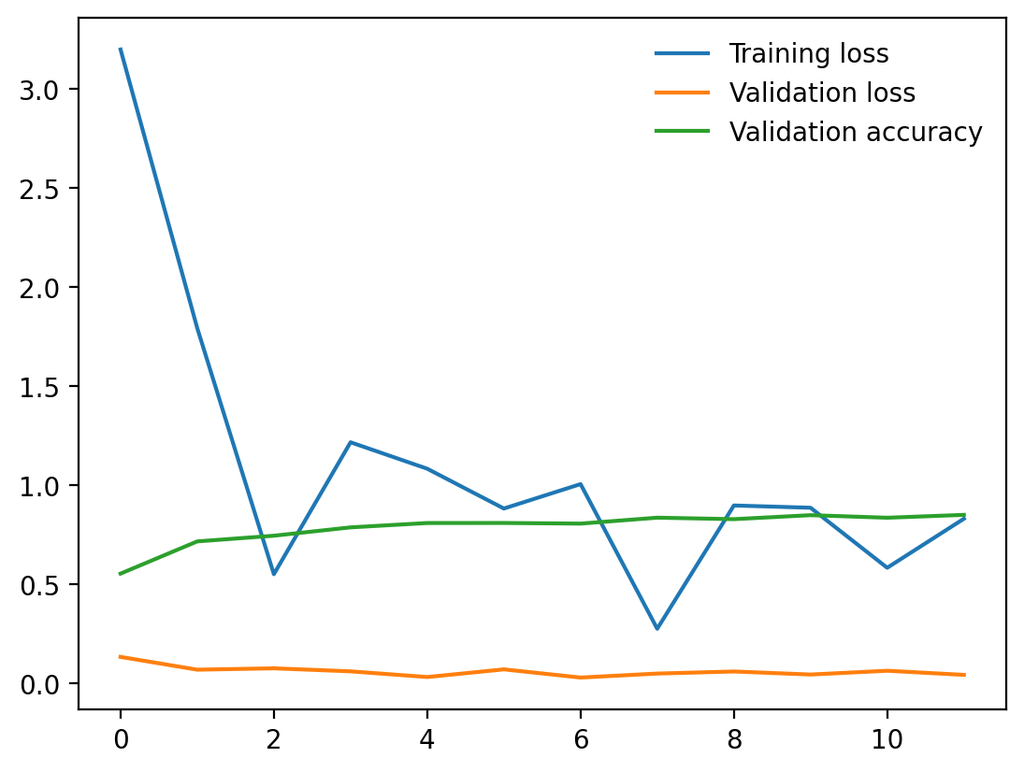

```python
train_model(model, train_loader, criterion, optimizer, epochs, gpu)
```

```python
def test_checker(testloader = test_loader, gpu = gpu):
    correct = 0
    total = 0

    #Moving to GPU based on user input
    if gpu == 'gpu':
        model.to('cuda')

    #Testing with the gradients turned off
    with torch.no_grad():
        for images, labels in testloader:
            if gpu == 'gpu':
                images, labels = images.to('cuda'), labels.to('cuda')

            #Calculating accuracy
            outputs = model(images)
            _, predicted = torch.max(outputs.data, 1)
            total += labels.size(0)
            correct += (predicted == labels).sum().item()
        print('Accuracy of the network on test data is: {}%'.format((correct / total) * 100))
```

```python
test_checker()
```

```
Accuracy of the network on test data is: 80.7081807081807%
```

```python
#The trained model is saved as a checkpoint along with associated hyperparameters and the class_to_idx dictionary

print("Our model: \n\n", model, '\n')
print("The state dict keys: \n\n", model.state_dict().keys())
model.class_to_idx = train_dataset.class_to_idx
model.cpu()
torch.save({'net': 'vgg16_bn',
            'state_dict': model.state_dict(),
            'class_to_idx': model.class_to_idx},
            'checkpoint.pth')
```

```
Our model:

 VGG(
  (features): Sequential(
    (0): Conv2d(3, 64, kernel_size=(3, 3), stride=(1, 1), padding=(1, 1))
    (1): ReLU(inplace=True)
    (2): Conv2d(64, 64, kernel_size=(3, 3), stride=(1, 1), padding=(1, 1))
    (3): ReLU(inplace=True)
    (4): MaxPool2d(kernel_size=2, stride=2, padding=0, dilation=1, ceil_mode=False)
    (5): Conv2d(64, 128, kernel_size=(3, 3), stride=(1, 1), padding=(1, 1))
    (6): ReLU(inplace=True)
    (7): Conv2d(128, 128, kernel_size=(3, 3), stride=(1, 1), padding=(1, 1))
    (8): ReLU(inplace=True)
    (9): MaxPool2d(kernel_size=2, stride=2, padding=0, dilation=1, ceil_mode=False)
    (10): Conv2d(128, 256, kernel_size=(3, 3), stride=(1, 1), padding=(1, 1))
    (11): ReLU(inplace=True)
    (12): Conv2d(256, 256, kernel_size=(3, 3), stride=(1, 1), padding=(1, 1))
    (13): ReLU(inplace=True)
    (14): Conv2d(256, 256, kernel_size=(3, 3), stride=(1, 1), padding=(1, 1))
    (15): ReLU(inplace=True)
    (16): MaxPool2d(kernel_size=2, stride=2, padding=0, dilation=1, ceil_mode=False)
    (17): Conv2d(256, 512, kernel_size=(3, 3), stride=(1, 1), padding=(1, 1))
    (18): ReLU(inplace=True)
    (19): Conv2d(512, 512, kernel_size=(3, 3), stride=(1, 1), padding=(1, 1))
    (20): ReLU(inplace=True)
    (21): Conv2d(512, 512, kernel_size=(3, 3), stride=(1, 1), padding=(1, 1))
    (22): ReLU(inplace=True)
    (23): MaxPool2d(kernel_size=2, stride=2, padding=0, dilation=1, ceil_mode=False)
    (24): Conv2d(512, 512, kernel_size=(3, 3), stride=(1, 1), padding=(1, 1))
    (25): ReLU(inplace=True)
    (26): Conv2d(512, 512, kernel_size=(3, 3), stride=(1, 1), padding=(1, 1))
    (27): ReLU(inplace=True)
    (28): Conv2d(512, 512, kernel_size=(3, 3), stride=(1, 1), padding=(1, 1))
    (29): ReLU(inplace=True)
    (30): MaxPool2d(kernel_size=2, stride=2, padding=0, dilation=1, ceil_mode=False)
  )
  (avgpool): AdaptiveAvgPool2d(output_size=(7, 7))
  (classifier): Sequential(
    (dropout): Dropout(p=0.5, inplace=False)
    (fc1): Linear(in_features=25088, out_features=1024, bias=True)
    (relu1): ReLU()
    (fc2): Linear(in_features=1024, out_features=256, bias=True)
    (output): Linear(in_features=256, out_features=102, bias=True)
    (softmax): LogSoftmax(dim=1)
  )
)

The state dict keys:

 odict_keys(['features.0.weight', 'features.0.bias', 'features.2.weight', 'features.2.bias', 'features.5.weight', 'features.5.bias', 'features.7.weight', 'features.7.bias', 'features.10.weight', 'features.10.bias', 'features.12.weight', 'features.12.bias', 'features.14.weight', 'features.14.bias', '…
```

```python
#Loading checkpoints

def load_model(checkpoint_path):
    checkpoint = torch.load(checkpoint_path)
    net = checkpoint['net']
    model.class_to_idx = checkpoint['class_to_idx']
    model.load_state_dict(checkpoint['state_dict'])
    return model

loaded_model =load_model('checkpoint.pth')
print(loaded_model)
```

```
VGG(
  (features): Sequential(
    (0): Conv2d(3, 64, kernel_size=(3, 3), stride=(1, 1), padding=(1, 1))
    (1): ReLU(inplace=True)
    (2): Conv2d(64, 64, kernel_size=(3, 3), stride=(1, 1), padding=(1, 1))
    (3): ReLU(inplace=True)
    (4): MaxPool2d(kernel_size=2, stride=2, padding=0, dilation=1, ceil_mode=False)
    (5): Conv2d(64, 128, kernel_size=(3, 3), stride=(1, 1), padding=(1, 1))
    (6): ReLU(inplace=True)
    (7): Conv2d(128, 128, kernel_size=(3, 3), stride=(1, 1), padding=(1, 1))
    (8): ReLU(inplace=True)
    (9): MaxPool2d(kernel_size=2, stride=2, padding=0, dilation=1, ceil_mode=False)
    (10): Conv2d(128, 256, kernel_size=(3, 3), stride=(1, 1), padding=(1, 1))
    (11): ReLU(inplace=True)
    (12): Conv2d(256, 256, kernel_size=(3, 3), stride=(1, 1), padding=(1, 1))
    (13): ReLU(inplace=True)
    (14): Conv2d(256, 256, kernel_size=(3, 3), stride=(1, 1), padding=(1, 1))
    (15): ReLU(inplace=True)
    (16): MaxPool2d(kernel_size=2, stride=2, padding=0, dilation=1, ceil_mode=False)
    (17): Conv2d(256, 512, kernel_size=(3, 3), stride=(1, 1), padding=(1, 1))
    (18): ReLU(inplace=True)
    (19): Conv2d(512, 512, kernel_size=(3, 3), stride=(1, 1), padding=(1, 1))
    (20): ReLU(inplace=True)
    (21): Conv2d(512, 512, kernel_size=(3, 3), stride=(1, 1), padding=(1, 1))
    (22): ReLU(inplace=True)
    (23): MaxPool2d(kernel_size=2, stride=2, padding=0, dilation=1, ceil_mode=False)
    (24): Conv2d(512, 512, kernel_size=(3, 3), stride=(1, 1), padding=(1, 1))
    (25): ReLU(inplace=True)
    (26): Conv2d(512, 512, kernel_size=(3, 3), stride=(1, 1), padding=(1, 1))
    (27): ReLU(inplace=True)
    (28): Conv2d(512, 512, kernel_size=(3, 3), stride=(1, 1), padding=(1, 1))
    (29): ReLU(inplace=True)
    (30): MaxPool2d(kernel_size=2, stride=2, padding=0, dilation=1, ceil_mode=False)
  )
  (avgpool): AdaptiveAvgPool2d(output_size=(7, 7))
  (classifier): Sequential(
    (dropout): Dropout(p=0.5, inplace=False)
    (fc1): Linear(in_features=25088, out_features=1024, bias=True)
    (relu1): ReLU()
    (fc2): Linear(in_features=1024, out_features=256, bias=True)
    (output): Linear(in_features=256, out_features=102, bias=True)
    (softmax): LogSoftmax(dim=1)
  )
)
```

```python
def process_image(image):

    picture = Image.open(image)

    transform = transforms.Compose([transforms.Resize(256),
                                    transforms.CenterCrop(224),
                                    transforms.ToTensor(),
                                    transforms.Normalize([0.485, 0.456, 0.406],
                                                         [0.229, 0.224, 0.225])])

    np_array = transform(picture).float()

    return np_array

#processed_image = (test_dir + '/43/' + 'image_02365.jpg')
#processed_image = process_image(processed_image)
#print(processed_image.shape)
```

```python
def imshow(image, ax=None, title=None):
    if ax is None:
        fig, ax = plt.subplots()


    image = image.numpy().transpose((1, 2, 0))

    # Undo preprocessing
    mean = np.array([0.485, 0.456, 0.406])
    std = np.array([0.229, 0.224, 0.225])
    image = std * image + mean


    image = np.clip(image, 0, 1)

    ax.imshow(image)

    return ax
```

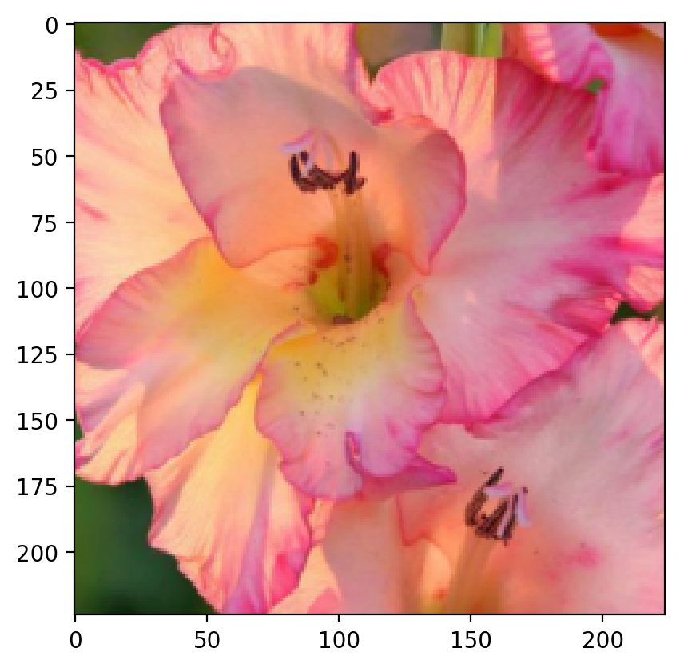

```python
imshow(process_image(data_dir + '/test/43/' + 'image_02431.jpg'));
```

```python
def predict(image_path, model, topk=5, gpu = gpu):
    ''' Predict the class (or classes) of an image using a trained deep learning model.
    '''

    #Processing image
    image = process_image(image_path)
    image = image.float().unsqueeze_(0)

    #Moving to GPU if user prompted
    if gpu == 'gpu':
        model.to('cuda:0')

    #Creating prediction score
    with torch.no_grad():
        if gpu == 'gpu':
            image = image.to('cuda')

        output = model.forward(image)

    prediction = F.softmax(output.data, dim = 1)

    probs, indices = prediction.topk(topk)
    probs = probs.cpu().numpy()[0]
    indices = indices.cpu().numpy()[0]

    idx_to_class = {v:k for k, v in model.class_to_idx.items()}
    classes = [idx_to_class[x] for x in indices]

    return probs, classes
```

```python
test_image = (data_dir + '/test/43/' + 'image_02431.jpg')
probs, classes = predict(test_image, loaded_model)
print(probs)
print(classes)
```

```
[0.50949305 0.44819954 0.03102183 0.00795345 0.00078305]
['43', '36', '72', '85', '18']
```

[figure not shown]

```python
def check_sanity(test_image = test_image, model = loaded_model):
    probs, classes = predict(test_image, model)
    flower_names = [cat_to_name[str(i)] for i in classes]

    #Creating our grids with matplotlib
    fig = plt.figure(figsize = (8, 8))
    ax1 = plt.subplot2grid((15, 9), (0,0), colspan = 9, rowspan = 9)
    ax2 = plt.subplot2grid((15, 9), (10,2), colspan = 5, rowspan = 5)

    #Showing the image itself
    image = Image.open(test_image)
    ax1.axis('off')
    ax1.set_title('Image of the Test Flower')
    ax1.imshow(image)

    #Showing the prediction graph
    y_ticks = np.arange(5)
    ax2.set_yticks(y_ticks)
    ax2.set_yticklabels(flower_names)
    ax2.set_title('Probability Chart')
    ax2.set_xlabel('Probability')
    ax2.set_ylabel('Flower Types')
    ax2.barh(y_ticks, probs, align = 'center')

    plt.show

check_sanity()
```